# Loan Interest Rate Prediction Data Visualization

### Monthly Income

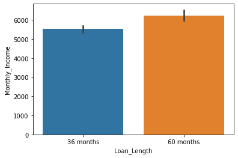

```python
sns.barplot(y = loan_data['Monthly_Income'], x = loan_data['Loan_Length'])
```

```
Avg monthly income for 60 months is more than tenure of 36 months

**Applicants who have chosen the payment tenure of 60 months have max avg monthly income.
```

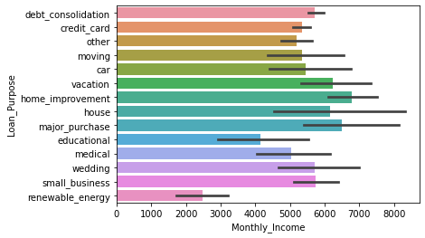

```python
sns.barplot(x = loan_data['Monthly_Income'], y = loan_data['Loan_Purpose'])
```

```
Applicants who have chosen loans for home improvement, major purchase, vacation, house have comparatively higher monthly income (avg.) - with high variability.
```

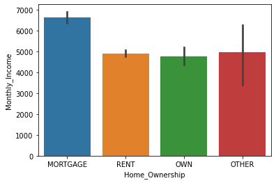

```python
sns.barplot(y = loan_data['Monthly_Income'], x = loan_data['Home_Ownership'])
```

```
Applicants with home ownership type as Mortgage have max avg. monthly income.
Applicants who are owners and on rent have similar monthly income range.
```

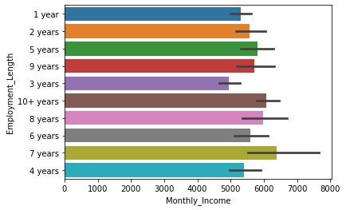

```python
sns.barplot(x = loan_data['Monthly_Income'], y = loan_data['Employment_Length'])
```

```
Applicants with above 7 years of employment experience have higher (avg) monthly income, where highest variability in income is found for applicants with 7 years experience.
Applicants with experience between 1-6 years have similar range of abg monthly income ~5500, with some variability in income in most of them.
Lowest is for 3 yrs of experience.
```

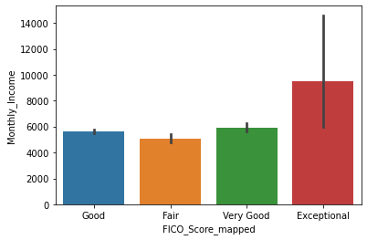

```python
sns.barplot(y = loan_data['Monthly_Income'], x = loan_data['FICO_Score_mapped'])
```

```
Applicants with FICO score as Exceptional, have higher monthly income than others. The error bar indicates, there are few applicants with Exceptional FICO score, who's avg. monthly income goes beyond 14000.
```

### INTEREST RATE

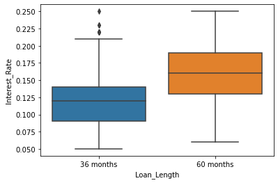

```python
sns.boxplot(x = loan_data['Loan_Length'], y = loan_data['Interest_Rate'])
```

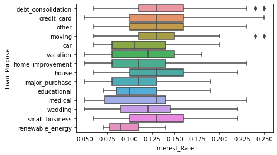

```python
sns.boxplot(y = loan_data['Loan_Purpose'], x = loan_data['Interest_Rate'])
```

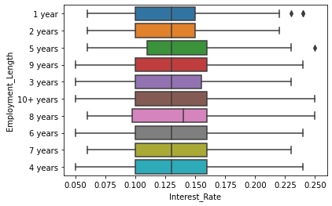

```python
sns.boxplot(y = loan_data['Employment_Length'], x = loan_data['Interest_Rate'])
```

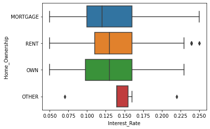

```python
sns.boxplot(y = loan_data['Home_Ownership'], x = loan_data['Interest_Rate'])
```

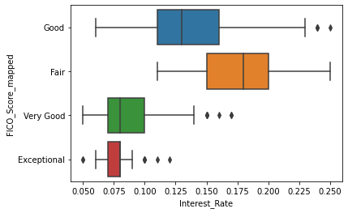

```python
sns.boxplot(y = loan_data['FICO_Score_mapped'], x = loan_data['Interest_Rate'])
```

### Revolving Credit Balance

sns.boxplot(x = loan_data['Inquiries_in_the_last_6months'], y = loan_data['Interest_Rate'])

[figure not shown]

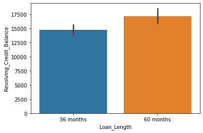

```python
sns.barplot(y = loan_data['Revolving_Credit_Balance'], x = loan_data['Loan_Length'])
```

```
Revolving credit balance (rcv) is more for applicants who have choosen 60 months as their payment tenure.
```

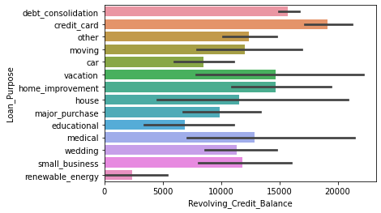

```python
sns.barplot(x = loan_data['Revolving_Credit_Balance'], y = loan_data['Loan_Purpose'])
```

[output not shown]

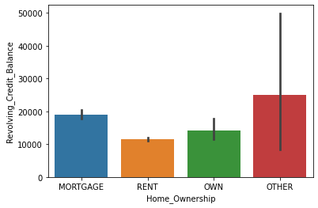

```python
sns.barplot(y = loan_data['Revolving_Credit_Balance'], x = loan_data['Home_Ownership'])
```

```
rcb for applicants with 'other' type of home ownership is higher as compared to mortgage, rent and owners. Few applicants of 'Other' home ownership type have rcb values higher than average.
```

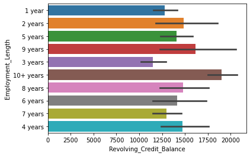

```python
sns.barplot(x = loan_data['Revolving_Credit_Balance'], y = loan_data['Employment_Length'])
```

```
applicants with more than 9 yrs of exp have higher avg rcb amongst all. Lowest is for 3 yrs of exp.
```

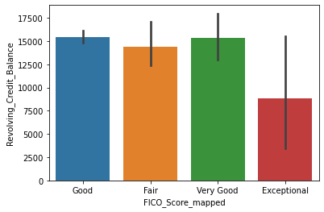

```python
sns.barplot(y = loan_data['Revolving_Credit_Balance'], x = loan_data['FICO_Score_mapped'])
```

```
avg rcb is highest for applicants with FICO score good & Very good. Few applicants with FICO score as 'Exceptional' have high rcb values.
```

### Inquiries in the last 6 months

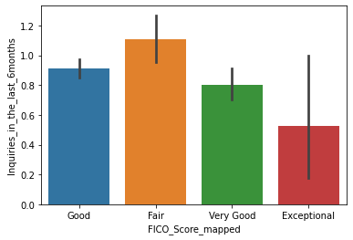

```python
sns.barplot(y = loan_data['Inquiries_in_the_last_6months'], x = loan_data['FICO_Score_mapped'])
```

```
Applicants with FICO score as Fair had more inquiries for credit history than others. Applicants with exceptional fico score had the lowest no. of inquiries for credit history, except for a few applicants where the inquiries made were more.
```

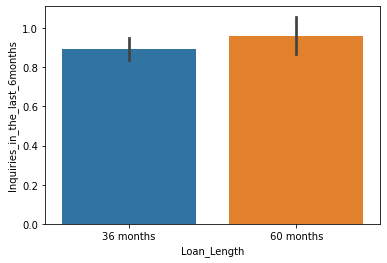

```python
sns.barplot(y = loan_data['Inquiries_in_the_last_6months'], x = loan_data['Loan_Length'])
```

```
applicant with payment tenure of 60 months - have had comparatively more inquiries than 36 months
```

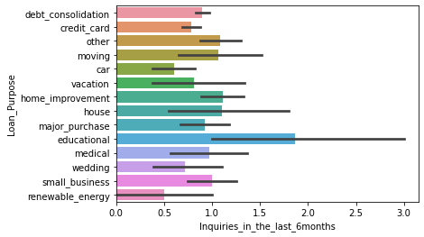

```python
sns.barplot(x = loan_data['Inquiries_in_the_last_6months'], y = loan_data['Loan_Purpose'])
```

```
More inquiries to credit histories were made on those applicants who had taken loans for educational purpose.
For loan purposes like - other, moving, home improvement, house, small businesses - similar # of inquirires to credit history are made.
```

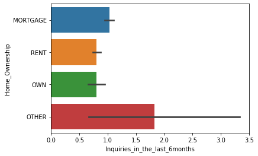

```python
sns.barplot(x = loan_data['Inquiries_in_the_last_6months'], y = loan_data['Home_Ownership'])
```

```
request for inquiries of credit history is more for applicants with 'Other' type of home ownership and lesser for owners and rent. There are few applicants in 'Other' category for which more inquiries of credit history was made.
```

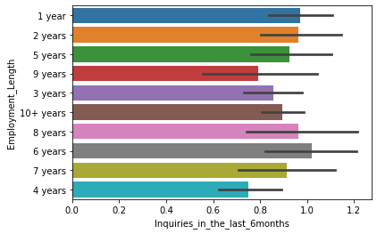

```python
sns.barplot(x = loan_data['Inquiries_in_the_last_6months'], y = loan_data['Employment_Length'])
```

```
Inquiries on credit history is made more on those applicants who's employment length is 6 yrs and less on applicants with 4 yrs/9 yrs.
```

### Debt To Income Ratio

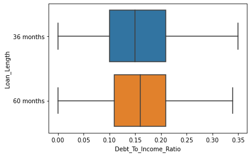

```python
sns.boxplot(y = loan_data['Loan_Length'], x = loan_data['Debt_To_Income_Ratio'])
```

```
There is not much difference between the dti for both the payment tenure.
Avg. dti ratio is slightly more for applicants with 60 months payment tenure than 36 months payment tenure.
75% of the applicants (from both payment tenures) have dti below ~0.21 percent.
```

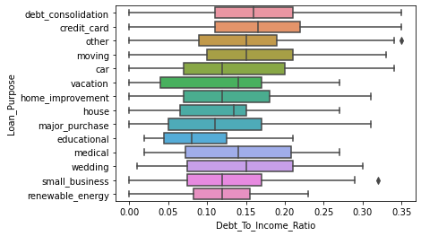

```python
sns.boxplot(y = loan_data['Loan_Purpose'], x = loan_data['Debt_To_Income_Ratio'])
```

```
* avg. dti for applicants who have applied for educational loan is lowest mongst all.
* loan purposes for which the applicants have good dti (median ~0.15%) are credit card, debt consolidation, other, moving, wedding. Also, 75% of applicants with good dti follow under these loan purposes.
* loan purposes of the applicants with dti below ~0.10 (25% of applicants payment tenures of 36-60 months) are - other, moving, car, vacation, home improvement, house, major purchases, educational, medical, wedding, small business, renewable energy.
* There is not much difference in dti amongst dti of all loan purposes.

LESS IS GOOD.
```

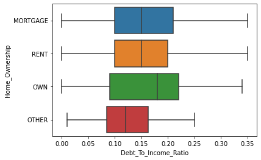

```python
sns.boxplot(y = loan_data['Home_Ownership'], x = loan_data['Debt_To_Income_Ratio'])
```

```
avg dti of HO other is lower/better as compared to other HO types.
avg dti for applicants with HO type as mortgage and rent is same ~0.15.
avg dti of applicants with HO type as Owners is highest.
The avg dti of all the HO type doesnot have much difference.
```

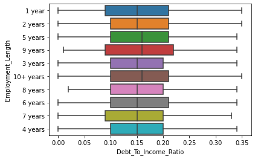

```python
sns.boxplot(y = loan_data['Employment_Length'], x = loan_data['Debt_To_Income_Ratio'])
```

```
avg dti of applicants across all employemnt length is almost same ~0.15.
```

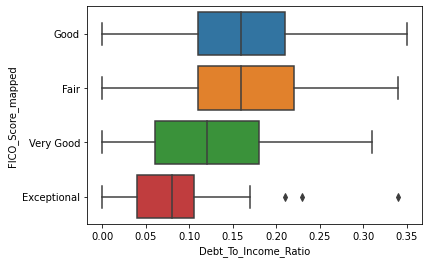

```python
sns.boxplot(y = loan_data['FICO_Score_mapped'], x = loan_data['Debt_To_Income_Ratio'])
```

```
Applicants with FICO score as Good & Fair have almost same avg dti ratio.
Low dti is of applicants with FICO score Exceptional (<0.10). 75% of the applicants (with exceptional fico score) are below 0.10 dti ratio. Few applicants of this fico score have high dti ratio.
```

### Bifurcation w.r.t Interest Rate

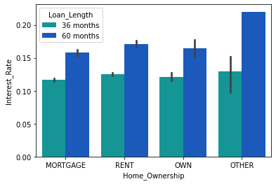

```python
sns.barplot(x='Home_Ownership',y='Interest_Rate',hue = 'Loan_Length', data=loan_data, palette='winter_r')
```

[output not shown]

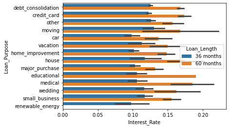

```python
sns.barplot(y='Loan_Purpose',x='Interest_Rate',hue = 'Loan_Length', data=loan_data)
```

[output not shown]

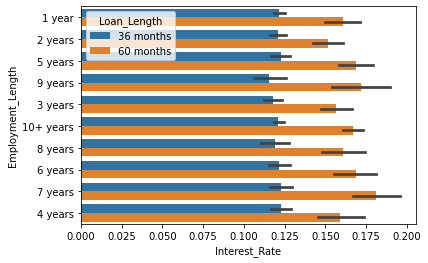

```python
sns.barplot(y='Employment_Length',x='Interest_Rate',hue = 'Loan_Length', data=loan_data)
```

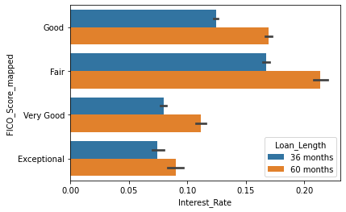

```python
sns.barplot(y='FICO_Score_mapped',x='Interest_Rate',hue = 'Loan_Length', data=loan_data)
```

```
** applicants with large # of payemnts have higher avg int rate.
36- highest avg int rate is for applicants with fico score as FAIR. Lowest is of aplicants with exceptional fico score.
60- highest avg ont rate is for applicants with fico score as Fair. Lowest is of applicants with exceptional fico score.
```

sns.barplot(x='Home_Ownership',y='Amount_Requested', data=loan_data, palette='winter_r')

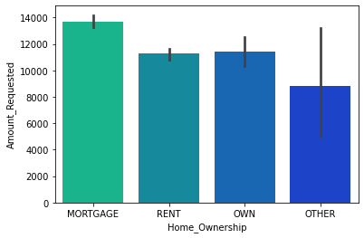

sns.barplot(x='Home_Ownership',y='Amount_Funded_By_Investors', data=loan_data, palette='winter_r')

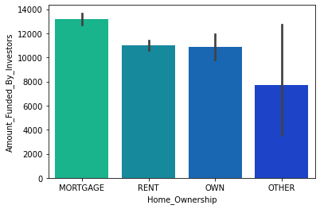

sns.barplot(y='Loan_Purpose',x='Amount_Funded_By_Investors', data=loan_data, palette='winter_r')

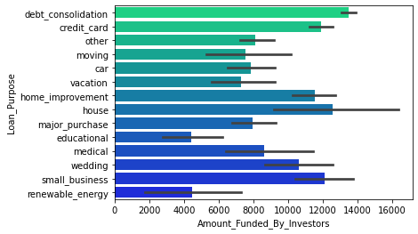

### chec it again

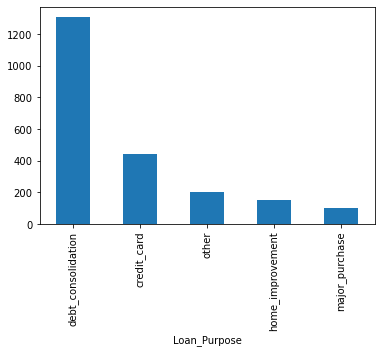

```python
loan_data.groupby('Loan_Purpose').Amount_Funded_By_Investors.count().sort_values(ascending=False)[:5].plot.bar()
```

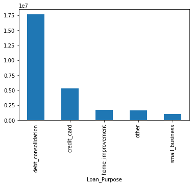

```python
loan_data.groupby('Loan_Purpose').Amount_Funded_By_Investors.sum().sort_values(ascending=False)[:5].plot.bar()
```

##### values should be multiplied by 1e7 (which is 1 x 10^7) or 10,000,000 (ten million)

```
AMount funded by Investors - loan purpose-wise.
```

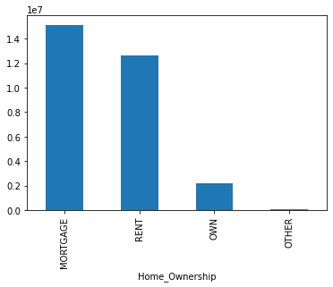

```python
loan_data.groupby('Home_Ownership').Amount_Funded_By_Investors.sum().sort_values(ascending=False)[:5].plot.bar()
```

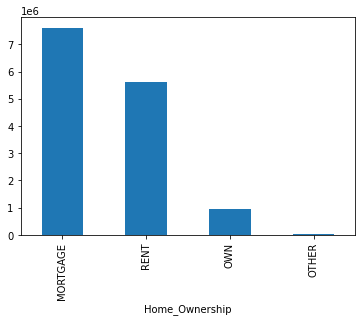

```python
loan_data.groupby('Home_Ownership').Monthly_Income.sum().sort_values(ascending=False)[:5].plot.bar()
```

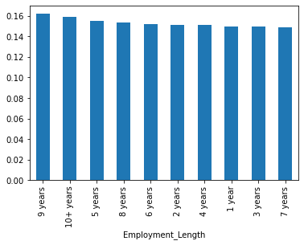

```python
loan_data.groupby('Employment_Length').Debt_To_Income_Ratio.mean().sort_values(ascending=False).plot.bar()
```

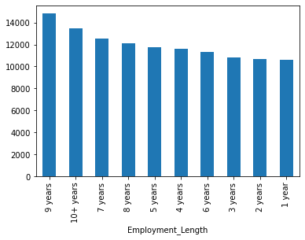

```python
loan_data.groupby('Employment_Length').Amount_Funded_By_Investors.mean().sort_values(ascending=False).plot.bar()
```

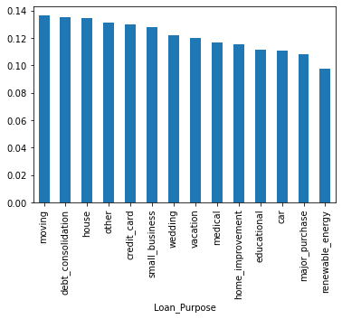

```python
loan_data.groupby('Loan_Purpose').Interest_Rate.mean().sort_values(ascending=False).plot.bar()
```

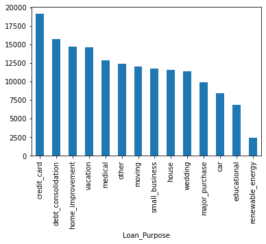

```python
loan_data.groupby('Loan_Purpose').Revolving_Credit_Balance.mean().sort_values(ascending=False).plot.bar()
```

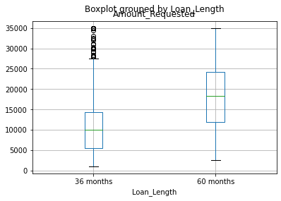

```python
loan_data.boxplot(column='Amount_Requested', by='Loan_Length')
```

### ---------------- Till here ------------

### Amount Funded by Investors- related details

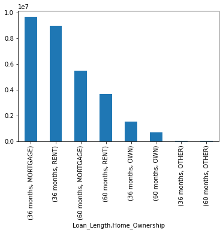

```python
loan_data.groupby(['Loan_Length','Home_Ownership']).Amount_Funded_By_Investors.sum().sort_values(ascending=False)[:10].plot.bar()
```

```
Investors funded majorly on applicants with 36 months payment tenure and HO type mortgage & Rent.  For 60 months payment tenure, the investors funded majorly on HO type mortgage.
```

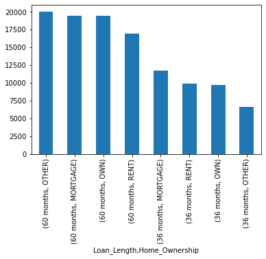

```python
loan_data.groupby(['Loan_Length','Home_Ownership']).Amount_Requested.mean().sort_values(ascending=False)[:10].plot.bar()
```

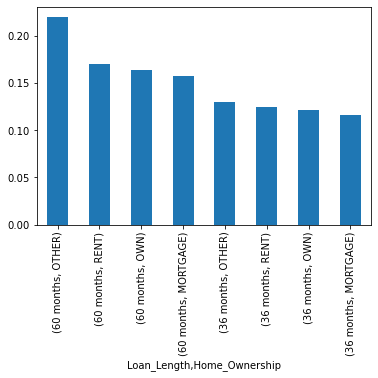

```python
loan_data.groupby(['Loan_Length','Home_Ownership']).Interest_Rate.mean().sort_values(ascending=False)[:10].plot.bar()
```

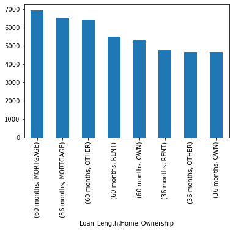

```python
loan_data.groupby(['Loan_Length','Home_Ownership']).Monthly_Income.mean().sort_values(ascending=False)[:10].plot.bar()
```

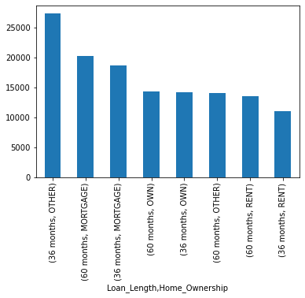

```python
loan_data.groupby(['Loan_Length','Home_Ownership']).Revolving_Credit_Balance.mean().sort_values(ascending=False)[:10].plot.bar()
```

#### Loan Length, Loan Purpose - Related details

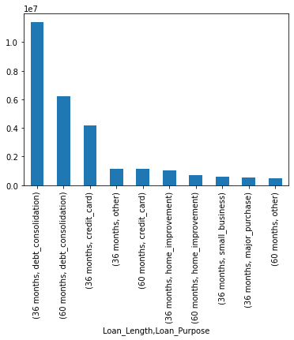

```python
loan_data.groupby(['Loan_Length','Loan_Purpose']).Amount_Funded_By_Investors.sum().sort_values(ascending=False)[:10].plot.bar()
```

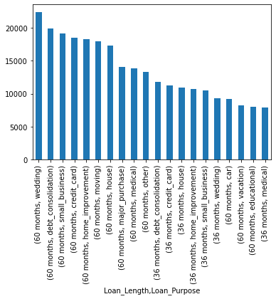

```python
loan_data.groupby(['Loan_Length','Loan_Purpose']).Amount_Requested.mean().sort_values(ascending=False)[:20].plot.bar()
```

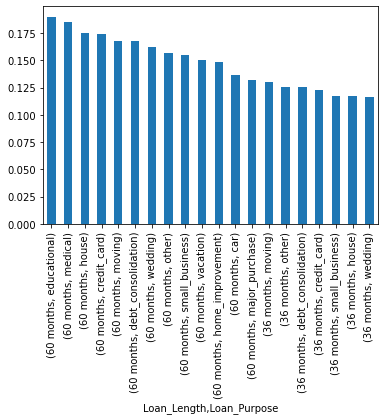

```python
loan_data.groupby(['Loan_Length','Loan_Purpose']).Interest_Rate.mean().sort_values(ascending=False)[:20].plot.bar()
```

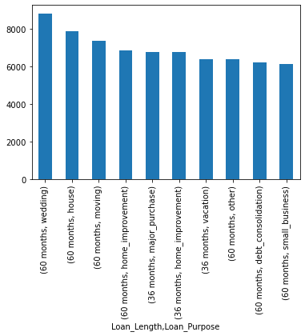

```python
loan_data.groupby(['Loan_Length','Loan_Purpose']).Monthly_Income.mean().sort_values(ascending=False)[:10].plot.bar()
```

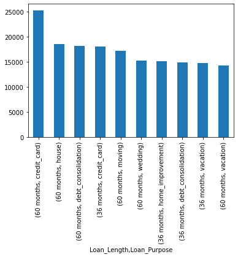

```python
loan_data.groupby(['Loan_Length','Loan_Purpose']).Revolving_Credit_Balance.mean().sort_values(ascending=False)[:10].plot.bar()
```

#### Loan length - Employment Length - Related details

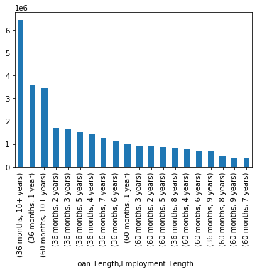

```python
loan_data.groupby(['Loan_Length','Employment_Length']).Amount_Funded_By_Investors.sum().sort_values(ascending=False)[:20].plot.bar()
```

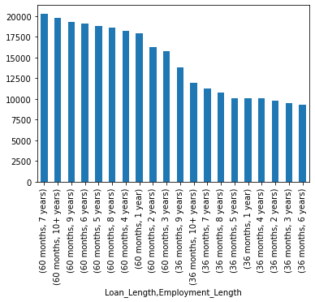

```python
loan_data.groupby(['Loan_Length','Employment_Length']).Amount_Requested.mean().sort_values(ascending=False)[:20].plot.bar()
```

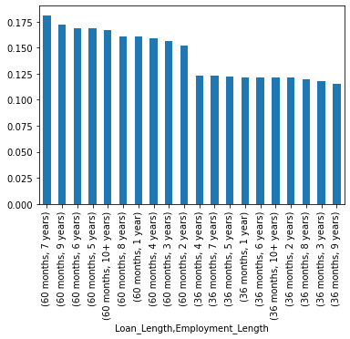

```python
loan_data.groupby(['Loan_Length','Employment_Length']).Interest_Rate.mean().sort_values(ascending=False)[:20].plot.bar()
```

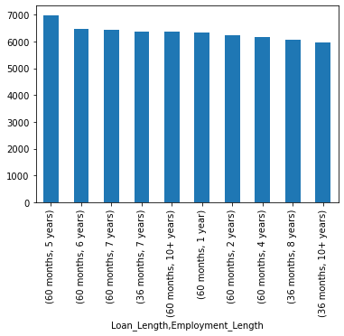

```python
loan_data.groupby(['Loan_Length','Employment_Length']).Monthly_Income.mean().sort_values(ascending=False)[:10].plot.bar()
```

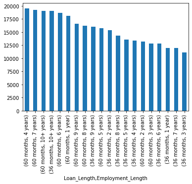

```python
loan_data.groupby(['Loan_Length','Employment_Length']).Revolving_Credit_Balance.mean().sort_values(ascending=False)[:20].plot.bar()
```

#### Loan Length + FICO Score

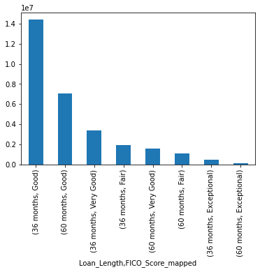

```python
loan_data.groupby(['Loan_Length','FICO_Score_mapped']).Amount_Funded_By_Investors.sum().sort_values(ascending=False)[:10].plot.bar()
```

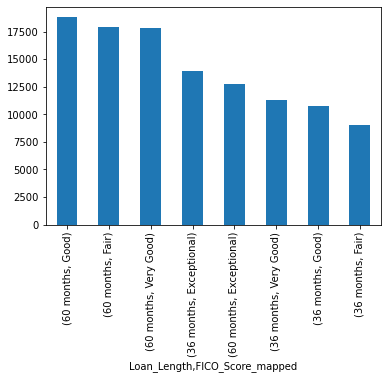

```python
loan_data.groupby(['Loan_Length','FICO_Score_mapped']).Amount_Requested.mean().sort_values(ascending=False)[:10].plot.bar()
```

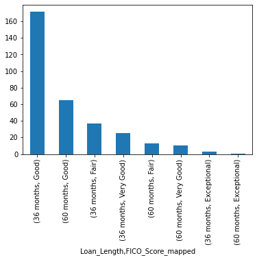

```python
loan_data.groupby(['Loan_Length','FICO_Score_mapped']).Interest_Rate.sum().sort_values(ascending=False)[:10].plot.bar()
```

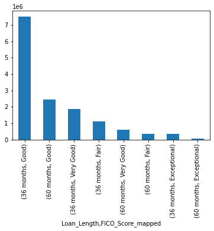

```python
loan_data.groupby(['Loan_Length','FICO_Score_mapped']).Monthly_Income.sum().sort_values(ascending=False)[:10].plot.bar()
```

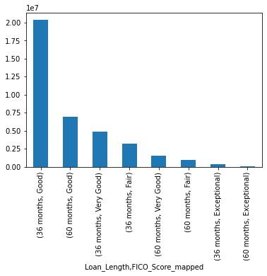

```python
loan_data.groupby(['Loan_Length','FICO_Score_mapped']).Revolving_Credit_Balance.sum().sort_values(ascending=False)[:10].plot.bar()
```